# 5Assessment2

rachelxi

20 March 2015

## Data Processing

The first step is to load the data from working directory.

```r
setwd("~/Documents/Datascience/5Assessment2")
data<-read.csv(bzfile("repdata-data-StormData.csv.bz2"))
```

Then, as referred to codebook from National Weather Service, 48 primary weather events are defined and related data is extracted from the original one. Besides, as population heath and economic loss would be investigated in the report, 8 columns of orginial data are introduced (“BGN_DATE”,“EVTYPE”,“FATALITIES”,“INJURIES”,“PROPDMG”,“PROPDMGEXP”,“CROPDMG”,“CROPDMGEXP”).The processed data is substituted into a new variable, StormData.

```r
Event <- c("ASTRONOMICAL LOW TIDE","AVALANCHE","BLIZZARD",
         "COASTAL FLOOD","COLD/WIND CHILL","DEBRIS FLOW",
         "DENSE FOG","DENSE SMOKE","DROUGHT","DUST DEVIL",
         "DUST STORM","EXCESSIVE HEAT","EXTREME COLD/WIND CHILL",
         "FLASH FLOOD","FLOOD","FREEZING FOG","FROST/FREEZE",
         "FUNNEL CLOUD","HAIL","HEAT","HEAVY RAIN","HEAVY SNOW",
         "HIGH SURF","HIGH WIND","HURRICANE/TYPHOON","ICE STORM",
         "LAKESHORE FLOOD","LAKE-EFFECT SNOW","LIGHTNING",
         "MARINE HAIL","MARINE HIGH WIND","MARINE STRONG WIND",
         "MARINE THUNDERSTORM","RIP CURRENT","SEICHE","SLEET",
         "STORM TIDE","STORM WIND","THUNDERSTORM WIND","TORNADO",
         "TROPICAL DEPRESSION","TROPICAL STORM","TSUNAMI",
         "VOLCANIC ASH","WATERSPOUT","WILDFIRE","WINTER STORM",
         "WINTER WEATHER")
index <- NULL
INDICATOR <- rep(0,length(data$EVTYPE))
for(i in 1:48){
    inter <- which(data$EVTYPE==Event[i])
    INDICATOR[inter] <- Event[i]
    index <- c(index,inter)
    inter <- NULL
}
data1 <- cbind(data[,2],INDICATOR,data[,23:28])
StormData <- data1[index,]
colnames(StormData) <- c("BGN_DATE","EVTYPE","FATALITIES","INJURIES",
                         "PROPDMG","PROPDMGEXP","CROPDMG","CROPDMGEXP")
```

As the report will take a look at the data with respect to time interval, an extra column defining the occured time of event is appended to the StormData as well. 10 years are considered as one interval in this case.

```r
YEAR <- rep(0,length(StormData$BGN_DATE))
inter <- grep(195,StormData$BGN_DATE)
YEAR[inter] <- 1950
inter <- grep(196,StormData$BGN_DATE)
YEAR[inter] <- 1960
inter <- grep(197,StormData$BGN_DATE)
YEAR[inter] <- 1970
inter <- grep(198,StormData$BGN_DATE)
YEAR[inter] <- 1980
inter <- grep(199,StormData$BGN_DATE)
YEAR[inter] <- 1990
inter <- grep(200,StormData$BGN_DATE)
YEAR[inter] <- 2000
inter <- grep(201,StormData$BGN_DATE)
YEAR[inter] <- 2010
StormData <- cbind(StormData,YEAR)
```

## The weather event that has the largest effect on fatalies and injuries across US during 1950-2011

To begin with, fatalities for all type of events are displayed:

```r
tapply(StormData$FATALITIES,StormData$EVTYPE,sum)
```

```
##                       0   ASTRONOMICAL LOW TIDE               AVALANCHE
##                      NA                       0                     224
##                BLIZZARD           COASTAL FLOOD         COLD/WIND CHILL
##                     101                       3                      95
##               DENSE FOG             DENSE SMOKE                 DROUGHT
##                      18                       0                       0
##              DUST DEVIL              DUST STORM          EXCESSIVE HEAT
##                       2                      22                    1903
## EXTREME COLD/WIND CHILL             FLASH FLOOD                   FLOOD
##                     125                     978                     470
##            FREEZING FOG            FROST/FREEZE            FUNNEL CLOUD
##                       0                       0                       0
##                    HAIL                    HEAT              HEAVY RAIN
##                      15                     937                      98
##              HEAVY SNOW               HIGH SURF               HIGH WIND
##                     127                     101                     248
##       HURRICANE/TYPHOON               ICE STORM        LAKE-EFFECT SNOW
##                      64                      89                       0
##         LAKESHORE FLOOD               LIGHTNING             MARINE HAIL
##                       0                     816                       0
##        MARINE HIGH WIND      MARINE STRONG WIND             RIP CURRENT
##                       1                      14                     368
##                  SEICHE                   SLEET       THUNDERSTORM WIND
##                       0                       2                     133
##                 TORNADO     TROPICAL DEPRESSION          TROPICAL STORM
##                    5633                       0                      58
##                 TSUNAMI            VOLCANIC ASH              WATERSPOUT
##                      33                       0                       3
##                WILDFIRE            WINTER STORM          WINTER WEATHER
##                      75                     206                      33
```

The maximum overall fatalities is from Tornado:

```r
max(tapply(StormData$FATALITIES,StormData$EVTYPE,sum),na.rm=TRUE)
```

```
## [1] 5633
```

Second, injuries for all event types would be:

```r
tapply(StormData$INJURIES,StormData$EVTYPE,sum)
```

```
##                       0   ASTRONOMICAL LOW TIDE               AVALANCHE
##                      NA                       0                     170
##                BLIZZARD           COASTAL FLOOD         COLD/WIND CHILL
##                     805                       2                      12
##               DENSE FOG             DENSE SMOKE                 DROUGHT
##                     342                       0                       4
##              DUST DEVIL              DUST STORM          EXCESSIVE HEAT
##                      42                     440                    6525
## EXTREME COLD/WIND CHILL             FLASH FLOOD                   FLOOD
##                      24                    1777                    6789
##            FREEZING FOG            FROST/FREEZE            FUNNEL CLOUD
##                       0                       0                       3
##                    HAIL                    HEAT              HEAVY RAIN
##                    1361                    2100                     251
##              HEAVY SNOW               HIGH SURF               HIGH WIND
##                    1021                     152                    1137
##       HURRICANE/TYPHOON               ICE STORM        LAKE-EFFECT SNOW
##                    1275                    1975                       0
##         LAKESHORE FLOOD               LIGHTNING             MARINE HAIL
##                       0                    5230                       0
##        MARINE HIGH WIND      MARINE STRONG WIND             RIP CURRENT
##                       1                      22                     232
##                  SEICHE                   SLEET       THUNDERSTORM WIND
##                       0                       0                    1488
##                 TORNADO     TROPICAL DEPRESSION          TROPICAL STORM
##                   91346                       0                     340
##                 TSUNAMI            VOLCANIC ASH              WATERSPOUT
##                     129                       0                      29
##                WILDFIRE            WINTER STORM          WINTER WEATHER
##                     911                    1321                     398
```

The maximum overall injuries is from Tornado as well:

```r
max(tapply(StormData$INJURIES,StormData$EVTYPE,sum),na.rm=TRUE)
```

```
## [1] 91346
```

Following barplot with two panels display the fatalities and injuries from 1950-2011 due to tornado respectively:

```r
index <- which(StormData$EVTYPE=="TORNADO")
Tornado <- StormData[index,]
```

Fatilities related to tornado with respective to years:

```r
tapply(Tornado$FATALITIES,Tornado$YEAR,sum)
```

```
## 1950 1960 1970 1980 1990 2000 2010
## 1419  942  998  522  559  561  632
```

Injuries related to tornado with respective to years:

```r
tapply(Tornado$INJURIES,Tornado$YEAR,sum)
```

```
##  1950  1960  1970  1980  1990  2000  2010
## 14470 17265 21640 11297 11461  8351  6862
```

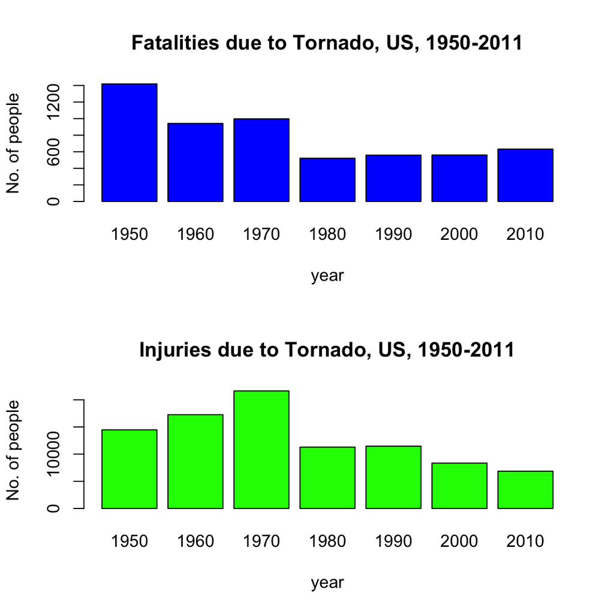

```r
Fatalities <- tapply(Tornado$FATALITIES,Tornado$YEAR,sum)
Injuries <- tapply(Tornado$INJURIES,Tornado$YEAR,sum)
Interval <- c(1950,1960,1970,1980,1990,2000,2010)
par(mfrow=c(2,1))
barplot(Fatalities,col="blue",xlab="year",ylab="No. of people",
        main="Fatalities due to Tornado, US, 1950-2011",
        names.arg=Interval)
barplot(Injuries,col="green",xlab="year",ylab="No. of people",
        main="Injuries due to Tornado, US, 1950-2011",
        names.arg=Interval)
```

## The weather event that has the largest effect on property and crop damage across US during 1950-2011

Since the number for damage and multiplier which indicates level (thousands,millions,billions) are separated in StormData, a proper processing is essential:

```r
PROPERTY <- rep(0,length(StormData$PROPDMG))
CROP <- rep(0,length(StormData$CROPDMG))
for(i in 1:length(PROPERTY)){
    inter1 <- StormData$PROPDMGEXP[i]
    inter2 <- StormData$PROPDMG[i]
    if(inter1=="K"){PROPERTY[i] <- inter2*1e3}
    if(inter1=="M"){PROPERTY[i] <- inter2*1e6}
    if(inter1=="B"){PROPERTY[i] <- inter2*1e9}
    else{PROPERTY[i] <- inter2}
}
for(i in 1:length(CROP)){
    inter1 <- StormData$CROPDMGEXP[i]
    inter2 <- StormData$CROPDMG[i]
    if(inter1=="K"){CROP[i] <- inter2*1e3}
    if(inter1=="M"){CROP[i] <- inter2*1e6}
    if(inter1=="B"){CROP[i] <- inter2*1e9}
    else{CROP[i] <- inter2}
}
StormData <- cbind(StormData,PROPERTY,CROP)
```

Similarly, economic losses on property for all type of events are displayed first:

```r
tapply(StormData$PROPERTY,StormData$EVTYPE,sum)
```

```
##                       0   ASTRONOMICAL LOW TIDE               AVALANCHE
##                      NA            3.200000e+02            1.623900e+03
##                BLIZZARD           COASTAL FLOOD         COLD/WIND CHILL
##            2.531848e+04            1.261084e+04            1.990000e+03
##               DENSE FOG             DENSE SMOKE                 DROUGHT
##            8.225450e+03            1.000000e+02            4.099050e+03
##              DUST DEVIL              DUST STORM          EXCESSIVE HEAT
##            7.003300e+02            5.049500e+03            1.460000e+03
## EXTREME COLD/WIND CHILL             FLASH FLOOD                   FLOOD
##            2.654000e+03            1.001420e+09            1.225009e+11
##            FREEZING FOG            FROST/FREEZE            FUNNEL CLOUD
##            1.840000e+02            9.685200e+02            1.946000e+02
##                    HAIL                    HEAT              HEAVY RAIN
##            1.800689e+09            2.985000e+02            5.084214e+04
##              HEAVY SNOW               HIGH SURF               HIGH WIND
##            1.222520e+05            3.041620e+03            1.300325e+09
##       HURRICANE/TYPHOON               ICE STORM        LAKE-EFFECT SNOW
##            6.550001e+10            6.600067e+04            1.414100e+04
##         LAKESHORE FLOOD               LIGHTNING             MARINE HAIL
##            4.750000e+01            6.033518e+05            4.000000e+00
##        MARINE HIGH WIND      MARINE STRONG WIND             RIP CURRENT
##            2.980100e+02            4.183300e+02            1.000000e+00
##                  SEICHE                   SLEET       THUNDERSTORM WIND
##            9.800000e+02            0.000000e+00            8.768442e+05
##                 TORNADO     TROPICAL DEPRESSION          TROPICAL STORM
##            5.303212e+09            7.380000e+02            5.150048e+09
##                 TSUNAMI            VOLCANIC ASH              WATERSPOUT
##            9.053000e+02            5.000000e+02            9.353700e+03
##                WILDFIRE            WINTER STORM          WINTER WEATHER
##            1.040084e+09            5.000133e+09            1.197490e+04
```

```r
max(tapply(StormData$PROPERTY,StormData$EVTYPE,sum),na.rm=TRUE)
```

```
## [1] 122500899816
```

Second, economic losses on crop are displayed:

```r
tapply(StormData$CROP,StormData$EVTYPE,sum)
```

```
##                       0   ASTRONOMICAL LOW TIDE               AVALANCHE
##                      NA            0.000000e+00            0.000000e+00
##                BLIZZARD           COASTAL FLOOD         COLD/WIND CHILL
##            1.720000e+02            0.000000e+00            6.000000e+02
##               DENSE FOG             DENSE SMOKE                 DROUGHT
##            0.000000e+00            0.000000e+00            1.500034e+09
##              DUST DEVIL              DUST STORM          EXCESSIVE HEAT
##            0.000000e+00            1.601500e+03            4.944000e+02
## EXTREME COLD/WIND CHILL             FLASH FLOOD                   FLOOD
##            5.000000e+01            1.792005e+05            1.680379e+05
##            FREEZING FOG            FROST/FREEZE            FUNNEL CLOUD
##            0.000000e+00            7.034140e+03            0.000000e+00
##                    HAIL                    HEAT              HEAVY RAIN
##            5.795963e+05            4.000007e+08            1.112280e+04
##              HEAVY SNOW               HIGH SURF               HIGH WIND
##            2.165720e+03            0.000000e+00            1.728321e+04
##       HURRICANE/TYPHOON               ICE STORM        LAKE-EFFECT SNOW
##            1.510005e+09            5.000002e+09            0.000000e+00
##         LAKESHORE FLOOD               LIGHTNING             MARINE HAIL
##            0.000000e+00            3.580610e+03            0.000000e+00
##        MARINE HIGH WIND      MARINE STRONG WIND             RIP CURRENT
##            0.000000e+00            0.000000e+00            0.000000e+00
##                  SEICHE                   SLEET       THUNDERSTORM WIND
##            0.000000e+00            0.000000e+00            6.679145e+04
##                 TORNADO     TROPICAL DEPRESSION          TROPICAL STORM
##            1.000185e+05            0.000000e+00            5.899120e+03
##                 TSUNAMI            VOLCANIC ASH              WATERSPOUT
##            2.000000e+01            0.000000e+00            0.000000e+00
##                WILDFIRE            WINTER STORM          WINTER WEATHER
##            4.364200e+03            1.978990e+03            1.500000e+01
```

```r
max(tapply(StormData$CROP,StormData$EVTYPE,sum),na.rm=TRUE)
```

```
## [1] 5000001684
```

```r
index <- which(StormData$EVTYPE=="HURRICANE/TYPHOON")
Hur_Typ <- StormData[index,]
index <- which(StormData$EVTYPE=="HAIL")
Hail <- StormData[index,]
```

Property loss related to hurricane/typhoon with respective to years:

```r
tapply(Hur_Typ$PROPERTY,Hur_Typ$YEAR,sum)
```

```
##        2000
## 65500005774
```

Crop loss related to hail with respective to years:

```r
tapply(Hail$CROP,Hail$YEAR,sum)
```

```
##     1950     1960     1970     1980     1990     2000     2010
##      0.0      0.0      0.0      0.0 216317.1 321822.2  41457.0
```

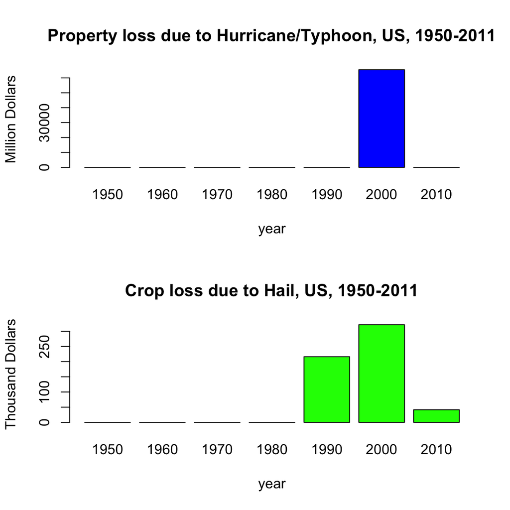

```r
inter <- tapply(Hur_Typ$PROPERTY,Hur_Typ$YEAR,sum)
Property <- c(0,0,0,0,0,inter,0)
names(Property)<-Interval
Crop <- tapply(Hail$CROP,Hail$YEAR,sum)
par(mfrow=c(2,1))
barplot(Property/1e6,col="blue",xlab="year",ylab="Million Dollars",
        main="Property loss due to Hurricane/Typhoon, US, 1950-2011",
        names.arg=Interval)
barplot(Crop/1e3,col="green",xlab="year",ylab="Thousand Dollars",
        main="Crop loss due to Hail, US, 1950-2011",
        names.arg=Interval)
```

## At last, the entire population health and economic losses with all types of events are explored below

Fatilities due to all weather events with respective to years:

```r
tapply(StormData$FATALITIES,StormData$YEAR,sum)
```

```
## 1950 1960 1970 1980 1990 2000 2010
## 1419  942  998  522 3744 3965 1405
```

Injuries due to all weather events with respective to years:

```r
tapply(StormData$INJURIES,StormData$YEAR,sum)
```

```
##  1950  1960  1970  1980  1990  2000  2010
## 14470 17265 21640 11519 30944 22246  9570
```

Property losses related to all weather events with respective to years:

```r
tapply(StormData$PROPERTY,StormData$YEAR,sum)
```

```
##         1950         1960         1970         1980         1990
## 2.376894e+05 3.284694e+05 5.121580e+05 5.452083e+05 8.002025e+09
##         2000         2010
## 1.889936e+11 1.160139e+10
```

Crop losses related to all weather events with respective to years:

```r
tapply(StormData$CROP,StormData$YEAR,sum)
```

```
##       1950       1960       1970       1980       1990       2000
##          0          0          0          0 5900359703 2510675222
##       2010
##     156142
```

```r
Fatalities <- tapply(StormData$FATALITIES,StormData$YEAR,sum)
Injuries <- tapply(StormData$INJURIES,StormData$YEAR,sum)
Property <- tapply(StormData$PROPERTY,StormData$YEAR,sum)
Crop <- tapply(StormData$CROP,StormData$YEAR,sum)
Health <- rbind(Fatalities,Injuries)
Economy <- rbind(Property,Crop)
```

Barplots are displayed in following:

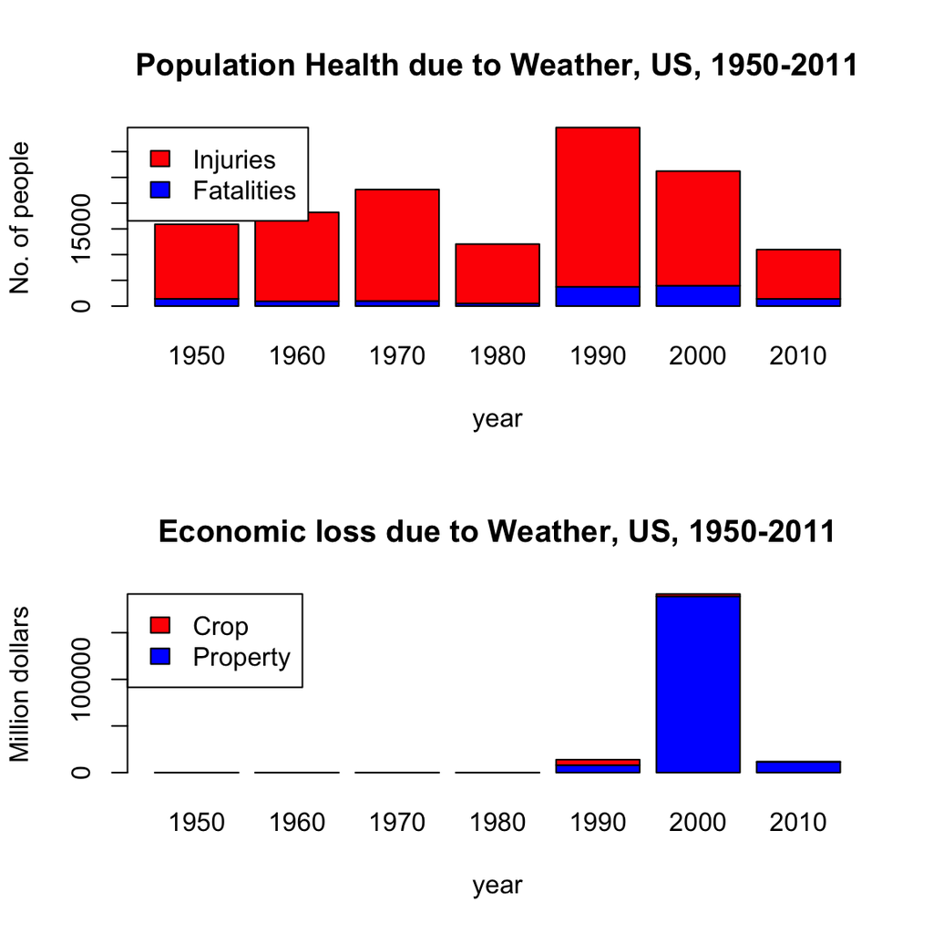

```r
par(mfrow=c(2,1))
barplot(Health,xlab="year",ylab="No. of people",
        main="Population Health due to Weather, US, 1950-2011",
        legend=rownames(Health),col=c("blue","red"),
        args.legend=list(x="topleft"))
barplot(Economy/1e6,xlab="year",ylab="Million dollars",
        main="Economic loss due to Weather, US, 1950-2011",
        legend=rownames(Economy),col=c("blue","red"),
        args.legend=list(x="topleft"))
```